# AllLife Bank Customer Segmentation

## Comparing K-Means Clustering and Hierarchical Clustering

- K-Means and Hierarchical clustering are giving the same results, except that the cluster numbers are interchanged.
- Dendograms took a little longer to plot in hierarchical clustering, I don't see any drawback since the data set is limited.

#### Comparing Scaled Data

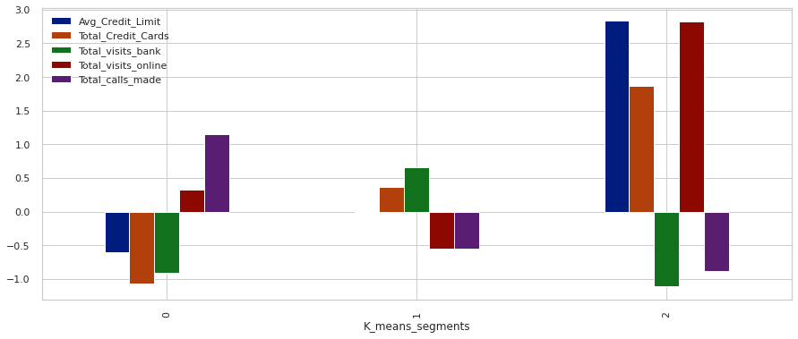

```python
kMeansDf.groupby("K_means_segments").mean().plot.bar(figsize=(15, 6))
```

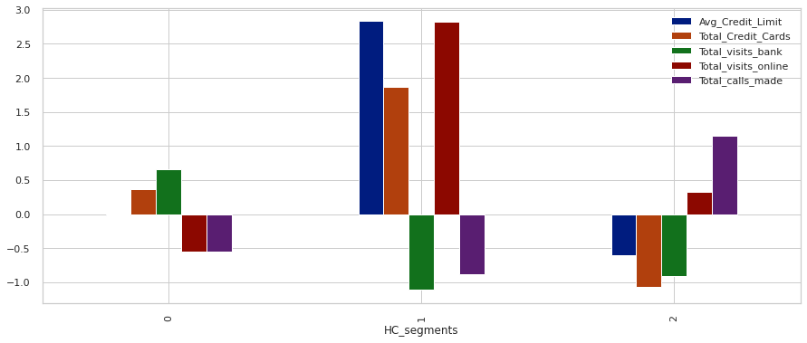

```python
HCdf.groupby("HC_segments").mean().plot.bar(figsize=(15, 6))
```

#### Comparing original Data

I am dividing the Avg_Credit_limit value by 10000 for better visualization, however the scaled data is used for interpretation purpose.

```python
profilingDf = ccardDf.copy()
```

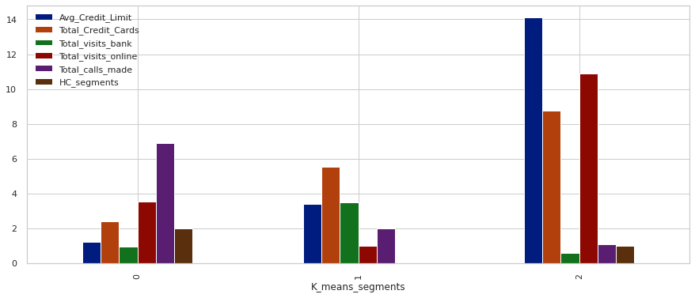

```python
profilingDf["Avg_Credit_Limit"] = profilingDf.Avg_Credit_Limit/10000
profilingDf.groupby("K_means_segments").mean().plot.bar(figsize=(15, 6))
```

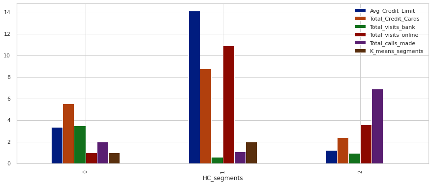

```python
profilingDf.groupby("HC_segments").mean().plot.bar(figsize=(15, 6))
```

```python
ccardDf.head()
```

|  | Avg_Credit_Limit | Total_Credit_Cards | Total_visits_bank | Total_visits_online | Total_calls_made | K_means_segments | HC_segments |
| --- | --- | --- | --- | --- | --- | --- | --- |
| 0 | 100000 | 2 | 1 | 1 | 0 | 1 | 0 |
| 1 | 50000 | 3 | 0 | 10 | 9 | 0 | 2 |
| 2 | 50000 | 7 | 1 | 3 | 4 | 1 | 0 |
| 3 | 30000 | 5 | 1 | 1 | 4 | 1 | 0 |
| 4 | 100000 | 6 | 0 | 12 | 3 | 2 | 1 |

**Let us label K-means and HC clusters with the same number for better interpretation and comparison between clusters**

```python
ccardDf.HC_segments = ccardDf.K_means_segments
ccardDf.head()
```

|  | Avg_Credit_Limit | Total_Credit_Cards | Total_visits_bank | Total_visits_online | Total_calls_made | K_means_segments | HC_segments |
| --- | --- | --- | --- | --- | --- | --- | --- |
| 0 | 100000 | 2 | 1 | 1 | 0 | 1 | 1 |
| 1 | 50000 | 3 | 0 | 10 | 9 | 0 | 0 |
| 2 | 50000 | 7 | 1 | 3 | 4 | 1 | 1 |
| 3 | 30000 | 5 | 1 | 1 | 4 | 1 | 1 |
| 4 | 100000 | 6 | 0 | 12 | 3 | 2 | 2 |

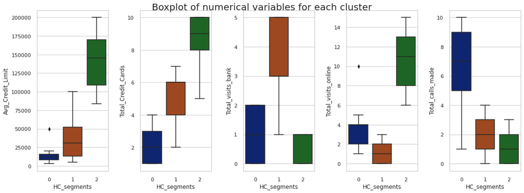

```python
fig, axes = plt.subplots(1, 5, figsize=(16, 6))
fig.suptitle(
    "Boxplot of numerical variables for each cluster",
    fontsize=20,
)

counter = 0

for ii in range(5):
    sns.boxplot(ax=axes[ii], y=ccardDf[ccardDf.columns[counter]], x=ccardDf["HC_segments"])
    counter = counter + 1

fig.tight_layout(pad=2.0)
```